# Missed Medical Appointments

- Introduction
- Data Wrangling
- Exploratory Data Analysis
- Conclusions

## Introduction

The dataset chosen for this analysis is the "No-Show appointments" downloaded from Kaggle. This dataset collects information from 100k medical appointments in Brazil and is focused on the question of whether or not patients show up for their appointment. The main objective of this analysis is to find a correlation within the data provided in order to understand, and possibly predict, if a patient will show up for their scheduled appointment.

## Data Dictionary

- **PatientId** - Identification of a patient
- **AppointmentID** - Identification of each appointment
- **Gender** = **Male** or **Female**
- **AppointmentDay** = The day of the actuall appointment, when they have to visit the doctor. **ScheduledDay** = The day someone called or registered the appointment, this is before appointment of course.
- **Age** = How old is the patient.
- **Neighbourhood** = Where the appointment takes place.
- **Scholarship** = **True** or **False** (More info in this article https://en.wikipedia.org/wiki/Bolsa_Fam%C3%ADlia)
- **Hipertension** = **True** or **False**
- **Diabetes** = **True** or **False**
- **Alcoholism** = **True** or **False**
- **Handcap** = Level of Handicap (0-4)
- **SMS_received** = 1 or more messages sent to the patient.
- **No-show** = **True** or **False**

## Data Wrangling

### Load Libraries and Data

```python
# importing all packages needed for the study

import pandas as pd
import numpy as np
import datetime as dt
import matplotlib.pyplot as plt
% matplotlib inline
import seaborn as sns
sns.set_style('darkgrid')
```

```python
# loading data from noshowappointments_may_2016.csv
df = pd.read_csv('noshowappointments_may_2016.csv')
```

In the below cells we will see the basic information about the data that we had loaded in the previous step.

```python
# Check for null values
df.info()
```

```
<class 'pandas.core.frame.DataFrame'>
RangeIndex: 110527 entries, 0 to 110526
Data columns (total 14 columns):
PatientId         110527 non-null float64
AppointmentID     110527 non-null int64
Gender            110527 non-null object
ScheduledDay      110527 non-null object
AppointmentDay    110527 non-null object
Age               110527 non-null int64
Neighbourhood     110527 non-null object
Scholarship       110527 non-null int64
Hipertension      110527 non-null int64
Diabetes          110527 non-null int64
Alcoholism        110527 non-null int64
Handcap           110527 non-null int64
SMS_received      110527 non-null int64
No-show           110527 non-null object
dtypes: float64(1), int64(8), object(5)
memory usage: 11.8+ MB
```

As we can see there are no NULL values in any of the columns.

```python
# Display the first 5 rows of the dataset to see if some reformatting is needed
df.head(5)
```

|  | PatientId | AppointmentID | Gender | ScheduledDay | AppointmentDay | Age | Neighbourhood | Scholarship | Hipertension | Diabetes | Alcoholism | Handcap | SMS_received | No-show |
| --- | --- | --- | --- | --- | --- | --- | --- | --- | --- | --- | --- | --- | --- | --- |
| 0 | 2.987250e+13 | 5642903 | F | 2016-04-29T18:38:08Z | 2016-04-29T00:00:00Z | 62 | JARDIM DA PENHA | 0 | 1 | 0 | 0 | 0 | 0 | No |
| 1 | 5.589978e+14 | 5642503 | M | 2016-04-29T16:08:27Z | 2016-04-29T00:00:00Z | 56 | JARDIM DA PENHA | 0 | 0 | 0 | 0 | 0 | 0 | No |
| 2 | 4.262962e+12 | 5642549 | F | 2016-04-29T16:19:04Z | 2016-04-29T00:00:00Z | 62 | MATA DA PRAIA | 0 | 0 | 0 | 0 | 0 | 0 | No |
| 3 | 8.679512e+11 | 5642828 | F | 2016-04-29T17:29:31Z | 2016-04-29T00:00:00Z | 8 | PONTAL DE CAMBURI | 0 | 0 | 0 | 0 | 0 | 0 | No |
| 4 | 8.841186e+12 | 5642494 | F | 2016-04-29T16:07:23Z | 2016-04-29T00:00:00Z | 56 | JARDIM DA PENHA | 0 | 1 | 1 | 0 | 0 | 0 | No |

```python
# renaming dataset columns to have consistent names
df.columns = [x.lower().replace("-","_") for x in df.columns]
```

```python
# check renaming
df.head(5)
```

|  | patientid | appointmentid | gender | scheduledday | appointmentday | age | neighbourhood | scholarship | hipertension | diabetes | alcoholism | handcap | sms_received | no_show |
| --- | --- | --- | --- | --- | --- | --- | --- | --- | --- | --- | --- | --- | --- | --- |
| 0 | 2.987250e+13 | 5642903 | F | 2016-04-29T18:38:08Z | 2016-04-29T00:00:00Z | 62 | JARDIM DA PENHA | 0 | 1 | 0 | 0 | 0 | 0 | No |
| 1 | 5.589978e+14 | 5642503 | M | 2016-04-29T16:08:27Z | 2016-04-29T00:00:00Z | 56 | JARDIM DA PENHA | 0 | 0 | 0 | 0 | 0 | 0 | No |
| 2 | 4.262962e+12 | 5642549 | F | 2016-04-29T16:19:04Z | 2016-04-29T00:00:00Z | 62 | MATA DA PRAIA | 0 | 0 | 0 | 0 | 0 | 0 | No |
| 3 | 8.679512e+11 | 5642828 | F | 2016-04-29T17:29:31Z | 2016-04-29T00:00:00Z | 8 | PONTAL DE CAMBURI | 0 | 0 | 0 | 0 | 0 | 0 | No |
| 4 | 8.841186e+12 | 5642494 | F | 2016-04-29T16:07:23Z | 2016-04-29T00:00:00Z | 56 | JARDIM DA PENHA | 0 | 1 | 1 | 0 | 0 | 0 | No |

## Data Cleaning

### Corrections:

Below we will correct some of the inconsistencies in the data:

- **patientid** and **appointmentid** are useless data so we will drop them.
- Data Type of **scheduledday** and **appointmentday** will be changed to DateTime.
- Typos in the Column names will be corrected
- As the 'appointmentday' has 00:00:00 in it's TimeStamp, we will ignore it.
- As we removed the Time from **appointmentday**'s TimeStamp we will do a similar thing for **scheduledday** also.
- Data Type of **scholarship**, **hypertension**, **diabetes**, **alcoholism**, **sms_received**, **no_show** will be changed to Boolean.
- Insert Columns **scheduledday_DOW** and **appointmentday_DOW**
- Check for typos in the dataset

```python
# Dropping useless columns
df.drop(['patientid', 'appointmentid'], axis=1, inplace=True)
df.head()
```

|  | gender | scheduledday | appointmentday | age | neighbourhood | scholarship | hipertension | diabetes | alcoholism | handcap | sms_received | no_show |
| --- | --- | --- | --- | --- | --- | --- | --- | --- | --- | --- | --- | --- |
| 0 | F | 2016-04-29T18:38:08Z | 2016-04-29T00:00:00Z | 62 | JARDIM DA PENHA | 0 | 1 | 0 | 0 | 0 | 0 | No |
| 1 | M | 2016-04-29T16:08:27Z | 2016-04-29T00:00:00Z | 56 | JARDIM DA PENHA | 0 | 0 | 0 | 0 | 0 | 0 | No |
| 2 | F | 2016-04-29T16:19:04Z | 2016-04-29T00:00:00Z | 62 | MATA DA PRAIA | 0 | 0 | 0 | 0 | 0 | 0 | No |
| 3 | F | 2016-04-29T17:29:31Z | 2016-04-29T00:00:00Z | 8 | PONTAL DE CAMBURI | 0 | 0 | 0 | 0 | 0 | 0 | No |
| 4 | F | 2016-04-29T16:07:23Z | 2016-04-29T00:00:00Z | 56 | JARDIM DA PENHA | 0 | 1 | 1 | 0 | 0 | 0 | No |

```python
# Convert scheduledday and appointmentday to 'datetime'
df['scheduledday'] = pd.to_datetime(df['scheduledday'])
df['scheduledday'] = pd.DatetimeIndex(df.scheduledday).normalize()
df['appointmentday'] = pd.to_datetime(df['appointmentday'])

# Rename incorrect column names.
df = df.rename(columns={'hipertension': 'hypertension', 'handcap': 'handicap'})

# Convert datatype from 'object' to 'boolean'
df.scholarship = df.scholarship.astype(bool)
df.hypertension = df.hypertension.astype(bool)
df.diabetes = df.diabetes.astype(bool)
df.alcoholism = df.alcoholism.astype(bool)
df.sms_received = df.sms_received.astype(bool)

df['no_show'] = df['no_show'] == "Yes"

# Create DOW columns
week = ['Monday','Tuesday','Wednesday','Thursday','Friday','Saturday','Sunday']
df['scheduledday_DOW'] = df['scheduledday'].dt.weekday_name
df['appointmentday_DOW'] = df['appointmentday'].dt.weekday_name

df.head()
```

|  | gender | scheduledday | appointmentday | age | neighbourhood | scholarship | hypertension | diabetes | alcoholism | handicap | sms_received | no_show | scheduledday_DOW | appointmentday_DOW |
| --- | --- | --- | --- | --- | --- | --- | --- | --- | --- | --- | --- | --- | --- | --- |
| 0 | F | 2016-04-29 | 2016-04-29 | 62 | JARDIM DA PENHA | False | True | False | False | 0 | False | False | Friday | Friday |
| 1 | M | 2016-04-29 | 2016-04-29 | 56 | JARDIM DA PENHA | False | False | False | False | 0 | False | False | Friday | Friday |
| 2 | F | 2016-04-29 | 2016-04-29 | 62 | MATA DA PRAIA | False | False | False | False | 0 | False | False | Friday | Friday |
| 3 | F | 2016-04-29 | 2016-04-29 | 8 | PONTAL DE CAMBURI | False | False | False | False | 0 | False | False | Friday | Friday |
| 4 | F | 2016-04-29 | 2016-04-29 | 56 | JARDIM DA PENHA | False | True | True | False | 0 | False | False | Friday | Friday |

```python
# Check datatypes
df.dtypes
```

```
gender                        object
scheduledday          datetime64[ns]
appointmentday        datetime64[ns]
age                            int64
neighbourhood                 object
scholarship                     bool
hypertension                    bool
diabetes                        bool
alcoholism                      bool
handicap                       int64
sms_received                    bool
no_show                         bool
scheduledday_DOW              object
appointmentday_DOW            object
dtype: object
```

### Check Data Values

```python
df.describe()
```

|  | age | handicap |
| --- | --- | --- |
| count | 110527.000000 | 110527.000000 |
| mean | 37.088874 | 0.022248 |
| std | 23.110205 | 0.161543 |
| min | -1.000000 | 0.000000 |
| 25% | 18.000000 | 0.000000 |
| 50% | 37.000000 | 0.000000 |
| 75% | 55.000000 | 0.000000 |
| max | 115.000000 | 4.000000 |

A minimum age of -1 is not possible, so i'm going to check which rows have an age value < 0

```python
# Check age < 0
df.query('age < 0')
```

|  | gender | scheduledday | appointmentday | age | neighbourhood | scholarship | hypertension | diabetes | alcoholism | handicap | sms_received | no_show | scheduledday_DOW | appointmentday_DOW |
| --- | --- | --- | --- | --- | --- | --- | --- | --- | --- | --- | --- | --- | --- | --- |
| 99832 | F | 2016-06-06 | 2016-06-06 | -1 | ROMÃO | False | False | False | False | 0 | False | False | Monday | Monday |

Because is only one row in the entire dataframe we can delete it.

```python
# Drop incorrect data row and check correction
df.drop(df.index[99832],inplace=True)
df.describe()
```

|  | age | handicap |
| --- | --- | --- |
| count | 110526.000000 | 110526.000000 |
| mean | 37.089219 | 0.022248 |
| std | 23.110026 | 0.161543 |
| min | 0.000000 | 0.000000 |
| 25% | 18.000000 | 0.000000 |
| 50% | 37.000000 | 0.000000 |
| 75% | 55.000000 | 0.000000 |
| max | 115.000000 | 4.000000 |

Now that the dataset is clean and incorrect values have been taken care of, we can move on to explore the data.

# Exploratory Data Analysis

Let's have a quick look at the most relevant values to see if we can find a particular correlation between the different values.

## Analyse Show/NoShow cases

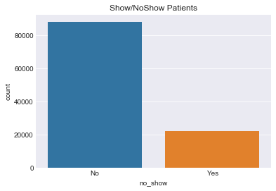

```python
# Plotting show/noshow cases
ax = sns.countplot(x=df.no_show)
ax.set_title("Show/NoShow Patients")
x_ticks_labels=['No', 'Yes']
ax.set_xticklabels(x_ticks_labels)
plt.show()
```

## Analyse gender distribution

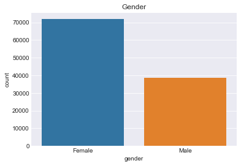

```python
# Plotting Gender division
ax = sns.countplot(x=df.gender)
ax.set_title("Gender")
x_ticks_labels=['Female', 'Male']
ax.set_xticklabels(x_ticks_labels)
plt.show()
```

### Does the gender influence show/no_show data?

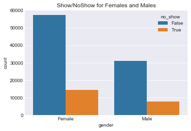

```python
# Plotting show/noshow cases over Gender
ax = sns.countplot(x=df.gender, hue=df.no_show)
ax.set_title("Show/NoShow for Females and Males")
x_ticks_labels=['Female', 'Male']
ax.set_xticklabels(x_ticks_labels)
plt.show()
```

As we can see, **female** patients have more appointments than **Male** patients and the cases in which they did **not** show up for the appointment are also higher for the women. But the no_show distribution looks almost the same for both, so i'm going to check the percentage of each one.

```python
# Calculate Women percentage
women_no_show = df[df.gender == 'F'].no_show.value_counts()[1]
women_total = df[df.gender == 'F'].shape[0]
perc_women = (women_no_show / women_total) * 100
perc_women
```

```
20.314870752655242
```

**20.31% of women did not show at the appointment**

```python
# Calculate men percentage
men_no_show = df[df.gender == 'M'].no_show.value_counts()[1]
men_total = df[df.gender == 'M'].shape[0]
perc_men = (men_no_show / men_total) * 100
perc_men
```

```
19.967947889471915
```

**19.97% of men did not show at the appointment**

And that confirmes our doubt; **Gender** is not playing an important role in determining if a patient comes for a visit or not.

## Analyse age distribution

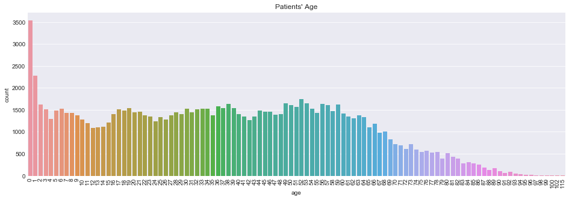

```python
# Plotting age distribution
plt.figure(figsize=(16,5))
ax = sns.countplot(x=df.age)
plt.xticks(rotation=90)
ax.set_title("Patients' Age")
plt.show()
```

```python
# Calculate Age mean
df.age.mean()
```

```
37.089218826339504
```

We can see that we have a majority of patients between 0-2 years old, then the distribution starts to be uniform until around 60 where we see a distribution skewed to the right.

The age mean is 37 years.

Let's plot the Age distribution with the show/noshow cases:

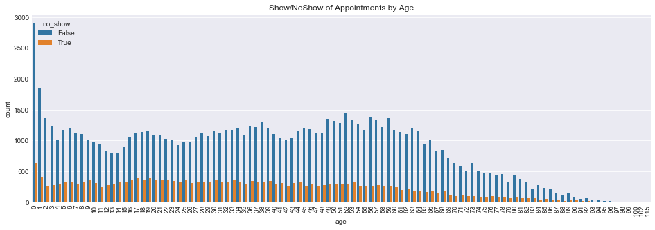

```python
# Plotting age over show/noshow cases
plt.figure(figsize=(16,5))
plt.xticks(rotation=90)
ax = sns.countplot(x=df.age, hue=df.no_show)
ax.set_title("Show/NoShow of Appointments by Age")
plt.show()
```

To get a better rappresentation we suddivide age into various groups.

```python
# Splitting patient's data into age groups
age_edges = [0,5,15,25,35,45,55,65,75,85,95,100]
age_bin = ['0-5','6-15','16-25','26-35','36-45','46-55','56-65','66-75','76-85','86-95','Over 100']
df['age_group'] = pd.cut(df['age'], age_edges, labels=age_bin)
df.head(5)
```

|  | gender | scheduledday | appointmentday | age | neighbourhood | scholarship | hypertension | diabetes | alcoholism | handicap | sms_received | no_show | scheduledday_DOW | appointmentday_DOW | age_group |
| --- | --- | --- | --- | --- | --- | --- | --- | --- | --- | --- | --- | --- | --- | --- | --- |
| 0 | F | 2016-04-29 | 2016-04-29 | 62 | JARDIM DA PENHA | False | True | False | False | 0 | False | False | Friday | Friday | 56-65 |
| 1 | M | 2016-04-29 | 2016-04-29 | 56 | JARDIM DA PENHA | False | False | False | False | 0 | False | False | Friday | Friday | 56-65 |
| 2 | F | 2016-04-29 | 2016-04-29 | 62 | MATA DA PRAIA | False | False | False | False | 0 | False | False | Friday | Friday | 56-65 |
| 3 | F | 2016-04-29 | 2016-04-29 | 8 | PONTAL DE CAMBURI | False | False | False | False | 0 | False | False | Friday | Friday | 6-15 |
| 4 | F | 2016-04-29 | 2016-04-29 | 56 | JARDIM DA PENHA | False | True | True | False | 0 | False | False | Friday | Friday | 56-65 |

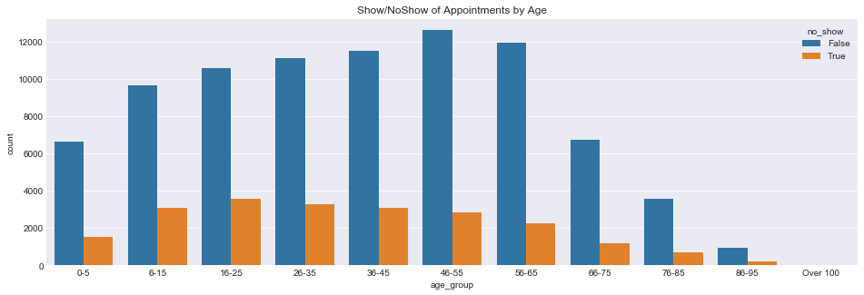

```python
# Plotting age over show/noshow cases
plt.figure(figsize=(16,5))
ax = sns.countplot(x=df.age_group, hue=df.no_show)
ax.set_title("Show/NoShow of Appointments by Age")
plt.show()
```

Let's have a look at the proportions of gender in each age group of the patients that did **not** show up at their appointment.

```python
# Group together for gender and age_group
group_count = df[df.no_show].groupby(['gender','age_group']).count()['age']
group_count
```

```
gender  age_group
F       0-5           740
        6-15         1533
        16-25        2553
        26-35        2383
        36-45        2162
        46-55        1925
        56-65        1581
        66-75         812
        76-85         454
        86-95         126
        Over 100        3
M       0-5           806
        6-15         1530
        16-25        1017
        26-35         899
        36-45         920
        46-55         909
        56-65         656
        66-75         384
        76-85         221
        86-95          62
        Over 100        1
Name: age, dtype: int64
```

```python
# Total count of 'not showed up' by the gender
group_totals = df[df.no_show].groupby('gender').count()['age']
group_totals
```

```
gender
F    14594
M     7725
Name: age, dtype: int64
```

```python
# Calculate men proportions
men_proportions = group_count['M'] / group_totals['M']
men_proportions
```

```
age_group
0-5         0.104337
6-15        0.198058
16-25       0.131650
26-35       0.116375
36-45       0.119094
46-55       0.117670
56-65       0.084919
66-75       0.049709
76-85       0.028608
86-95       0.008026
Over 100    0.000129
Name: age, dtype: float64
```

```python
# Calculate women proportions
women_proportions = group_count['F'] / group_totals['F']
women_proportions
```

```
age_group
0-5         0.050706
6-15        0.105043
16-25       0.174935
26-35       0.163286
36-45       0.148143
46-55       0.131904
56-65       0.108332
66-75       0.055639
76-85       0.031109
86-95       0.008634
Over 100    0.000206
Name: age, dtype: float64
```

```python
ind = np.arange(len(men_proportions))  # the x locations for the groups
width = 0.4
age_edges = ['0-5', '6-15', '16-25', '26-35', '36-45', '46-55', '56-65', '66-75', '76-85', '86-95', '96-100', 'Over 100']
```

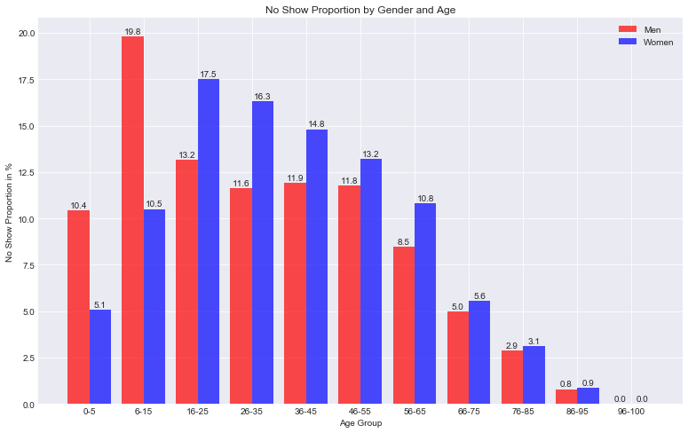

```python
plt.figure(figsize=(13,8))
# plot bars
med_bars = plt.bar(ind, men_proportions * 100, width, color='r', alpha=.7, label='Men')
women_bars = plt.bar(ind + width, women_proportions * 100, width, color='b', alpha=.7, label='Women')

for x,y in zip(ind,women_proportions * 100):
    plt.text(x+0.4, y+0.05, '%.1f' % y, ha='center', va= 'bottom')

for x,y in zip(ind-width,men_proportions * 100):
    plt.text(x+0.4, y+0.05, '%.1f' % y, ha='center', va= 'bottom')

# title and labels
plt.ylabel('No Show Proportion in %')
plt.xlabel('Age Group')
plt.title('No Show Proportion by Gender and Age')
locations = ind + width / 2  # xtick locations
labels = age_edges  # xtick labels
plt.xticks(locations, labels)


# legend
plt.legend();
```

We can clearly see that younger Male patients (6-15 years old) are the most popular group that doesn't show up at the appointment. For women instead we see a more normal distribution with the 16-25 group at the top.

## Analyse Neighbourhood

Let's see if the specific neighbourhood in which is located the hospital has some influence over the show/noshow cases.

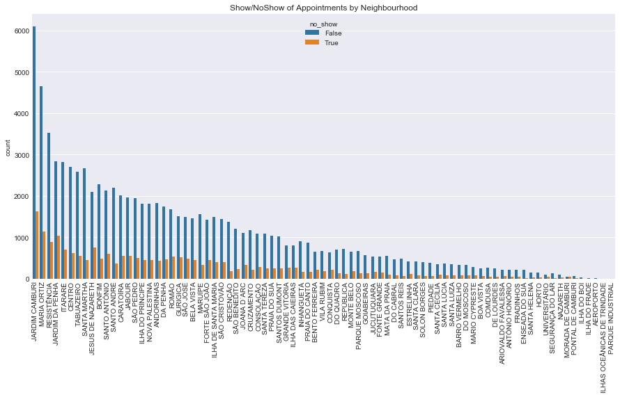

```python
# Plotting Show/NoShow of Appointments by Neighbourhood
plt.figure(figsize=(15,7))
plt.xticks(rotation=90)
ax = sns.countplot(x=np.sort(df.neighbourhood), hue=df.no_show, order=df.neighbourhood.value_counts().index)
ax.set_title("Show/NoShow of Appointments by Neighbourhood")
plt.show()
```

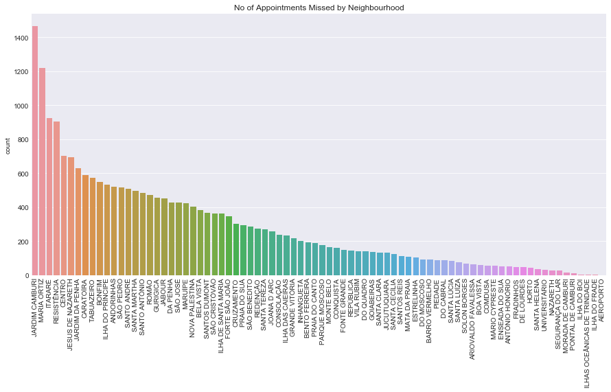

```python
# Potting No of Appointments Missed by Neighbourhood
plt.figure(figsize=(15,7))
plt.xticks(rotation=90)
ax = sns.countplot(x=np.sort(df[df.no_show].neighbourhood),order=df[df.no_show].neighbourhood.value_counts().index)
ax.set_title("No of Appointments Missed by Neighbourhood")
plt.show()
```

```python
# Calculating the top 3 neighbourhood with no_show cases
no_show = df[df.no_show].neighbourhood.value_counts()

no_show_perc = (no_show / no_show.sum()) * 100
no_show_perc.head(3)
```

```
JARDIM CAMBURI    6.563914
MARIA ORTIZ       5.461714
ITARARÉ           4.135490
Name: neighbourhood, dtype: float64
```

Top 3 Neighbourhood with the most NoShow cases:

1. **Jardim Camburi** - 6.56%
2. **Maria Ortiz** - 5.46%
3. **Itararé** - 4.13%

With these result we can't see a solid correlation between neighbourhood and 'not showed up' cases.

## Analyse Disease

Let's see if a specific disease has an impact over the show/noshow cases.

### Handicap

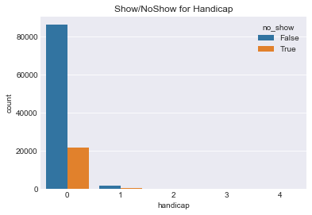

```python
# Plotting Show/NoShow for Handicap
ax = sns.countplot(x=df.handicap, hue=df.no_show)
ax.set_title("Show/NoShow for Handicap")
plt.show()
```

```python
# Number of patients with Handicap
df.handicap.value_counts()
```

```
0    108285
1      2042
2       183
3        13
4         3
Name: handicap, dtype: int64
```

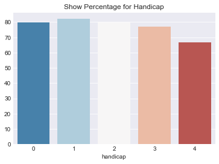

```python
# Plotting Percentage for Handicap
df_ha_ratio = df.query('not no_show').groupby(['handicap']).size()/df.groupby(['handicap']).size()
ax = sns.barplot(x=df_ha_ratio.index, y=df_ha_ratio*100, palette="RdBu_r")
ax.set_title("Show Percentage for Handicap")
plt.show()
```

From the graph just above we can see that a patient with an **Handicap** has around an 80% probability of showing up.

### Alcoholism

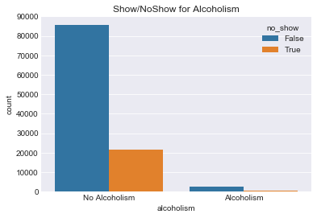

```python
# Plotting Show/NoShow for Alcoholism
ax = sns.countplot(x=df.alcoholism, hue=df.no_show)
ax.set_title("Show/NoShow for Alcoholism")
x_ticks_labels=['No Alcoholism', 'Alcoholism']
ax.set_xticklabels(x_ticks_labels)
plt.show()
```

```python
# Number of patients with Alcoholism
df.alcoholism.value_counts()
```

```
False    107166
True       3360
Name: alcoholism, dtype: int64
```

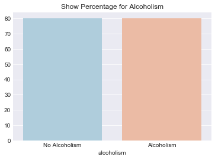

```python
# Plotting Percentage for Alcoholism
df_a_ratio = df.query('not no_show').groupby(['alcoholism']).size()/df.groupby(['alcoholism']).size()
ax = sns.barplot(x=df_a_ratio.index, y=df_a_ratio*100, palette="RdBu_r")
ax.set_title("Show Percentage for Alcoholism")
x_ticks_labels=['No Alcoholism', 'Alcoholism']
ax.set_xticklabels(x_ticks_labels)
plt.show()
```

The percentage of both cases is too similar so it doesn't give us useful data to evaluate the no_show probability

### Diabetes

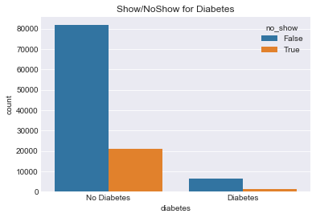

```python
# Plotting Show/NoShow for Diabetes
ax = sns.countplot(x=df.diabetes, hue=df.no_show)
ax.set_title("Show/NoShow for Diabetes")
x_ticks_labels=['No Diabetes', 'Diabetes']
ax.set_xticklabels(x_ticks_labels)
plt.show()
```

```python
# Number of patients with Diabetes
df.diabetes.value_counts()
```

```
False    102583
True       7943
Name: diabetes, dtype: int64
```

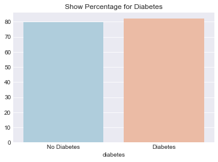

```python
# Plotting Percentage for Diabetes
df_d_ratio = df.query('not no_show').groupby(['diabetes']).size()/df.groupby(['diabetes']).size()
ax = sns.barplot(x=df_d_ratio.index, y=df_d_ratio*100, palette="RdBu_r")
ax.set_title("Show Percentage for Diabetes")
x_ticks_labels=['No Diabetes', 'Diabetes']
ax.set_xticklabels(x_ticks_labels)
plt.show()
```

Apparently patients affected by **Diabetes** are more likely to show up at the appointment.

### Hypertension

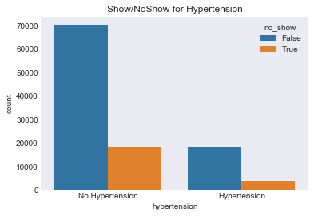

```python
# Plotting Show/NoShow for Hypertension
ax = sns.countplot(x=df.hypertension, hue=df.no_show)
ax.set_title("Show/NoShow for Hypertension")
x_ticks_labels=['No Hypertension', 'Hypertension']
ax.set_xticklabels(x_ticks_labels)
plt.show()
```

```python
# Number of patients with Hypertension
df.hypertension.value_counts()
```

```
False    88725
True     21801
Name: hypertension, dtype: int64
```

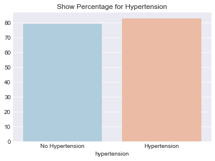

```python
# Plotting Percentage for Hypertension
df_h_ratio = df.query('not no_show').groupby(['hypertension']).size()/df.groupby(['hypertension']).size()
ax = sns.barplot(x=df_h_ratio.index, y=df_h_ratio*100, palette="RdBu_r")
ax.set_title("Show Percentage for Hypertension")
x_ticks_labels=['No Hypertension', 'Hypertension']
ax.set_xticklabels(x_ticks_labels)
plt.show()
```

Also **Hypertension** can give us useful data to determine if a patient will turn up for the visit

## Analyse Days of Week

Let's have a look at the weekdays of the appointments.

```python
# Number of appointments scheduled per weekday
df.scheduledday_DOW.value_counts()
```

```
Tuesday      26168
Wednesday    24262
Monday       23084
Friday       18915
Thursday     18073
Saturday        24
Name: scheduledday_DOW, dtype: int64
```

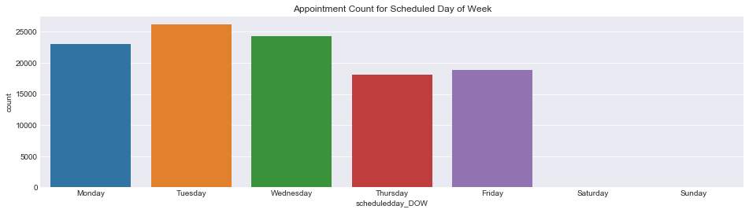

```python
# Plotting Appointment Count for Scheduled Day of Week
plt.figure(figsize=(16,4))
ax = sns.countplot(x=df.scheduledday_DOW, order=week)
ax.set_title("Appointment Count for Scheduled Day of Week")
plt.show()
```

```python
# Number of appointments per weekday
df.appointmentday_DOW.value_counts()
```

```
Wednesday    25867
Tuesday      25640
Monday       22714
Friday       19019
Thursday     17247
Saturday        39
Name: appointmentday_DOW, dtype: int64
```

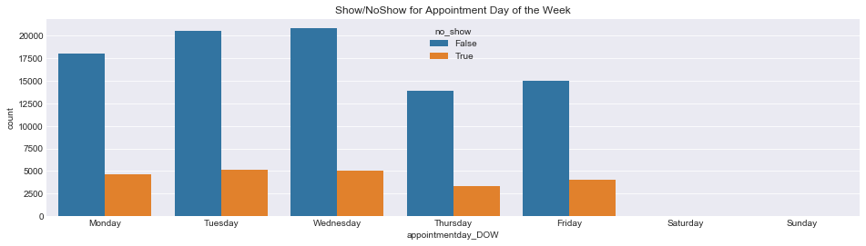

```python
# Plotting Show/NoShow for Appointment Day of the Week
plt.figure(figsize=(16,4))
ax = sns.countplot(x=df.appointmentday_DOW, hue=df.no_show, order=week)
ax.set_title("Show/NoShow for Appointment Day of the Week")
plt.show()
```

Let's have a look at a plot with percentages instead:

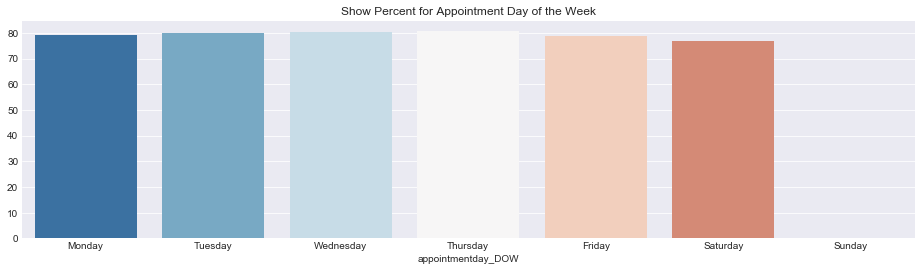

```python
# Plotting Percent for Appointment Day of the Week
df_a_dow_ratio = df.query('not no_show').groupby(['appointmentday_DOW']).size()/df.groupby(['appointmentday_DOW']).size()
plt.figure(figsize=(16,4))
ax = sns.barplot(x=df_a_dow_ratio.index, y=df_a_dow_ratio*100, order=week, palette="RdBu_r")
ax.set_title("Show Percent for Appointment Day of the Week")
plt.show()
```

```python
# Print Percentages
df_a_dow_ratio*100
```

```
appointmentday_DOW
Friday       78.773858
Monday       79.351942
Saturday     76.923077
Thursday     80.645909
Tuesday      79.906396
Wednesday    80.310821
dtype: float64
```

We can use this data to make our predictions thanks to Saturday's value because it is slightly less than the others.

## Analyse Waiting Time

```python
# Adding daydiff column to the df
df['scheduledday'] = pd.DatetimeIndex(df.scheduledday).normalize()

# Calculate the difference between appointmentday and scheduledday
df['daydiff'] = df['appointmentday'] - df['scheduledday']
df['daydiff'] = df['daydiff'].dt.days
```

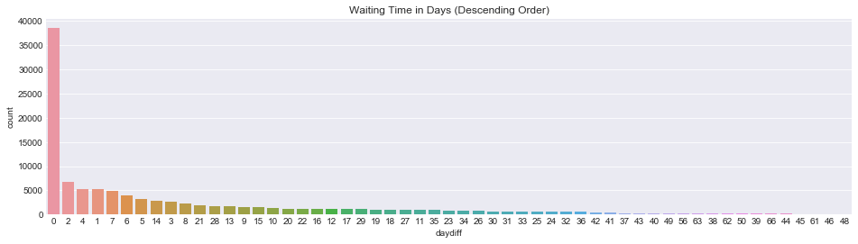

```python
# Plotting Waiting Time in Days
plt.figure(figsize=(16,4))
ax = sns.countplot(x=df.daydiff, order=df.daydiff.value_counts().iloc[:55].index)
ax.set_title("Waiting Time in Days (Descending Order)")
plt.show()
```

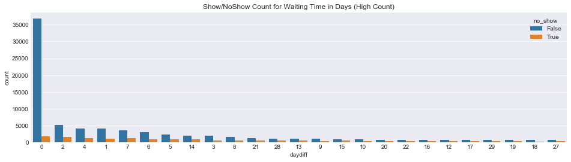

```python
# Plotting Show/NoShow Count for Waiting Time in Days
plt.figure(figsize=(16,4))
ax = sns.countplot(x=df.daydiff, hue=df.no_show, order=df.daydiff.value_counts().iloc[:25].index)
ax.set_title("Show/NoShow Count for Waiting Time in Days (High Count)")
plt.show()
```

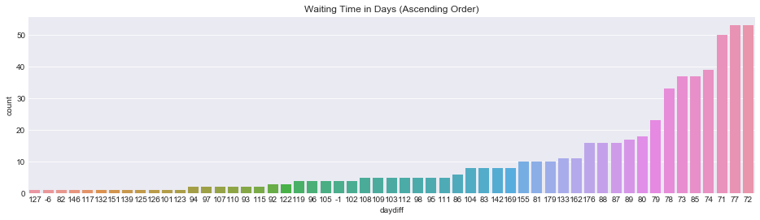

```python
# Plotting Waiting Time in Days
plt.figure(figsize=(16,4))
ax = sns.countplot(x=df.daydiff, order=df.daydiff.value_counts(ascending=True).iloc[:55].index)
ax.set_title("Waiting Time in Days (Ascending Order)")
plt.show()
```

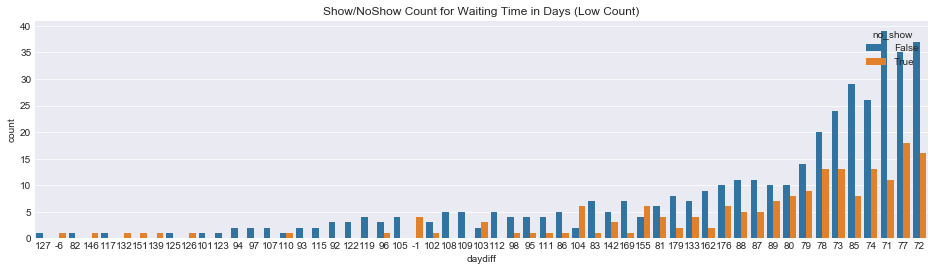

```python
# Plotting Show/NoShow Count for Waiting Time in Days
plt.figure(figsize=(16,4))
ax = sns.countplot(x=df.daydiff, hue=df.no_show, order=df.daydiff.value_counts(ascending=True).iloc[:55].index)
ax.set_title("Show/NoShow Count for Waiting Time in Days (Low Count)")
plt.show()
```

With these plots we can see that a patient is more likely to go to the appointment if he/she as to wait between 0-4 days. As the waiting increases, the No-Show cases increase too.

## Analyse Scholarship

```python
# Creating df_schol to get data more easily
df_schol = df[df.scholarship].copy()
# Dropping null values
df_schol.dropna(inplace=True)
df_schol.info()
```

```
<class 'pandas.core.frame.DataFrame'>
Int64Index: 10809 entries, 12 to 110482
Data columns (total 16 columns):
gender                10809 non-null object
scheduledday          10809 non-null datetime64[ns]
appointmentday        10809 non-null datetime64[ns]
age                   10809 non-null int64
neighbourhood         10809 non-null object
scholarship           10809 non-null bool
hypertension          10809 non-null bool
diabetes              10809 non-null bool
alcoholism            10809 non-null bool
handicap              10809 non-null int64
sms_received          10809 non-null bool
no_show               10809 non-null bool
scheduledday_DOW      10809 non-null object
appointmentday_DOW    10809 non-null object
age_group             10809 non-null category
daydiff               10809 non-null int64
dtypes: bool(6), category(1), datetime64[ns](2), int64(3), object(4)
memory usage: 918.7+ KB
```

Let's see how many patients that have not shown up are in the Bolsa Familia project.

```python
# Count of scholarships in 'not shown up' case
df_schol.no_show.value_counts()
```

```
False    8238
True     2571
Name: no_show, dtype: int64
```

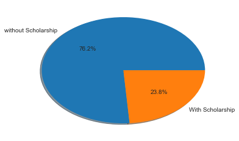

```python
# Plotting pie chart for Scholarships in 'not shown up' case
schol_value = df_schol.no_show.value_counts()
labels=['without Scholarship','With Scholarship']
plt.pie(schol_value, labels=labels, autopct='%1.1f%%', shadow=True);
```

As represented by the pie chart, the majority of the people that didn't show up is not in the Bolsa Familia project.

```python
# Patients with/without scholarship
df.scholarship.value_counts()
```

```
False    99665
True     10861
Name: scholarship, dtype: int64
```

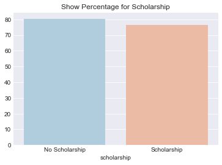

```python
# Plotting Percentage for Scholarship
df_s_ratio = df.query('not no_show').groupby(['scholarship']).size()/df.groupby(['scholarship']).size()
ax = sns.barplot(x=df_s_ratio.index, y=df_s_ratio*100, palette="RdBu_r")
ax.set_title("Show Percentage for Scholarship")
x_ticks_labels=['No Scholarship', 'Scholarship']
ax.set_xticklabels(x_ticks_labels)
plt.show()
```

From the above visualization we can see that around 80% of the 100000 patients without Scholarship have come for the visit. Out of the 10,800 patients with Scholarship around 75% of them have come for the visit. So, Scholarship feature could help us in determining if a patient will turn up for the visit after an appointment.

## Analyse SMS values

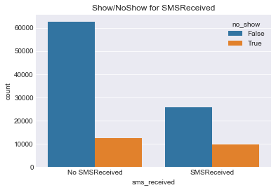

```python
# Plotting Show/NoShow for SMSReceived
ax = sns.countplot(x=df.sms_received, hue=df.no_show)
ax.set_title("Show/NoShow for SMSReceived")
x_ticks_labels=['No SMSReceived', 'SMSReceived']
ax.set_xticklabels(x_ticks_labels)
plt.show()
```

### General Case

```python
# Number of patients that have/haven't received an sms
df.sms_received.value_counts()
```

```
False    75044
True     35482
Name: sms_received, dtype: int64
```

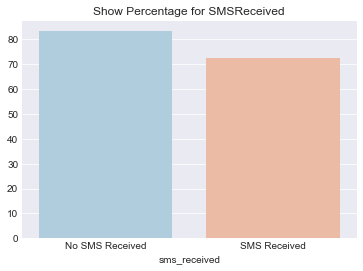

```python
# Plotting  Percentage for SMSReceived
df_s_ratio = df.query('not no_show').groupby(['sms_received']).size()/df.groupby(['sms_received']).size()
ax = sns.barplot(x=df_s_ratio.index, y=df_s_ratio*100, palette="RdBu_r")
ax.set_title("Show Percentage for SMSReceived")
x_ticks_labels=['No SMS Received', 'SMS Received']
ax.set_xticklabels(x_ticks_labels);
```

### No_Show case

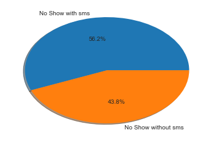

```python
# Plotting no_show case sms values
sms=df[df.no_show].sms_received.value_counts()
labels=['No Show with sms','No Show without sms']
plt.pie(sms, labels=labels, autopct='%1.1f%%', shadow=True);
```

Out of the 35,500 patients who **have** received SMS around **72%** of them have come for the visit.

As we can see a clear distinction between people reveiving SMS and not receiving SMS this feature will help us in determining if a patient will turn up for the visit after taking an appointment.